Mixed Effects Location Scale Model of Craving accompanying a poster at the EHPS 2025 in Groningen Christoph Bamberg August 2025

# Some resources:

1. https://bookdown.org/content/4857/adventures-in-covariance.html#summary-bonus-multilevel-growth-models-and-the-melsm
2. Williams, D. R., Liu, S., Martin, S. R., & Rast, P. (2019). Bayesian Multivariate Mixed-Effects Location Scale Modeling of Longitudinal Relations among Affective Traits, States, and Physical Activity. https://doi.org/10.31234/osf.io/4kfjp

```r
library(ggplot2)
library(brms)
library(rstan)
library(dplyr)
library(stringr)
library(tidyverse)
library(tidybayes)
library(modelr)
# some STAN settings
options(mc.cores = parallel::detectCores())
rstan_options(auto_write = TRUE)
```

```r
d = read.csv("data.csv",sep=",")
head(d)
```

```
##   X    alias craving signal day_of_week day_index day_index01 stressor
## 1 1 AEMR0604       7      0   Wednesday         1           0        0
## 2 2 AEMR0604      74      1   Wednesday         1           0        0
## 3 3 AEMR0604      66      2   Wednesday         1           0        0
## 4 4 AEMR0604      13      3   Wednesday         1           0        1
## 5 5 AEMR0604      10      4   Wednesday         1           0        1
## 6 6 AEMR0604      70      5   Wednesday         1           0        0
##   stressor_prev stress_gmc stress_smc   mood_gmc  mood_smc     mood alias_fct
## 1            NA  -7.832119    6.66242  11.479576 17.519108 74.83333  AEMR0604
## 2             0  -9.832119    4.66242  22.812909 28.852442 86.16667  AEMR0604
## 3             0  -3.832119   10.66242  20.479576 26.519108 83.83333  AEMR0604
## 4             0  56.167881   70.66242 -10.520424 -4.480892 52.83333  AEMR0604
## 5             1  31.167881   45.66242  16.979576 23.019108 80.33333  AEMR0604
## 6             1   1.167881   15.66242  -7.520424 -1.480892 55.83333  AEMR0604
##   id
## 1  1
## 2  1
## 3  1
## 4  1
## 5  1
## 6  1
```

```r
d1=subset(d,alias=="SLHR1002")
d2=subset(d,alias=="UERL0203")
length(unique(d$alias))
```

```
## [1] 64
```

```r
nrow(d)
```

```
## [1] 10920
```

# data exploration

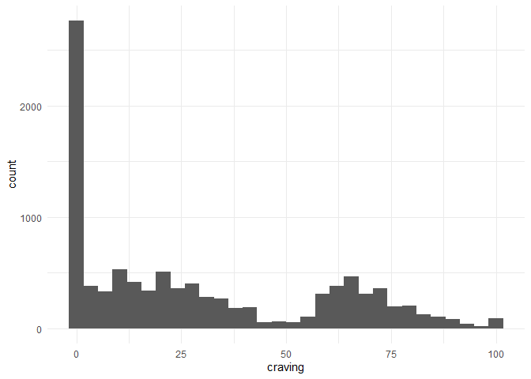

```r
ggplot(d,aes(x=craving))+geom_histogram()+theme_minimal()
```

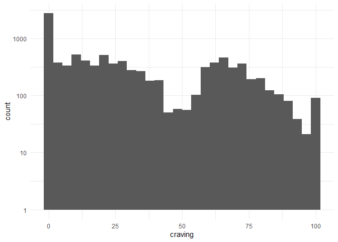

```r
ggplot(d,aes(x=craving))+geom_histogram()+scale_y_log10()+theme_minimal()
```

plotting craving fluctuations for participants

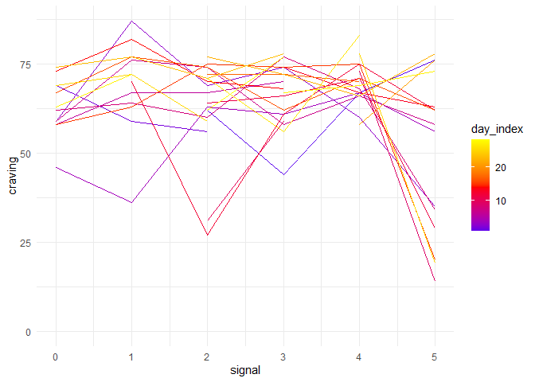

```r
#single participants
ggplot(d2,aes(x=signal,y=craving,group=day_index,colour=day_index))+geom_line()+      scale_colour_gradient2(low = "blue", mid = "red", high = "yellow", midpoint = 14)+theme_minimal()
```

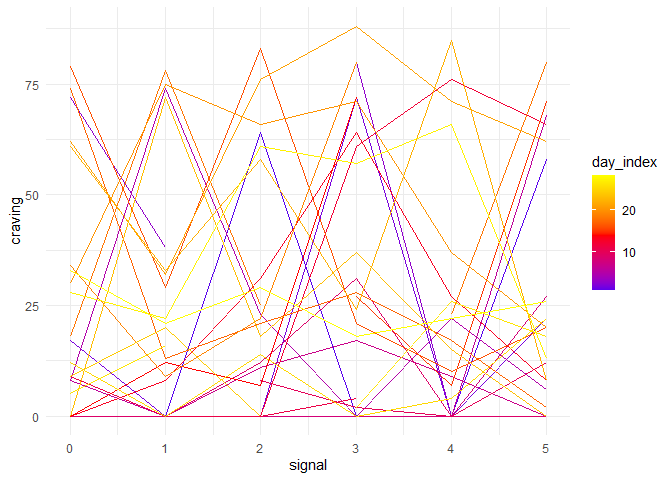

```r
ggplot(d1,aes(x=signal,y=craving,group=day_index,colour=day_index))+geom_line()+      scale_colour_gradient2(low = "blue", mid = "red", high = "yellow", midpoint = 14)+theme_minimal()
```

# typical Multi-level Model

for comparison

## starting with measurement repetition as only factor and craving as outcome

i.e., fixed intercept overall, fixed effect of time; varying intercept, varying effect of time.

```r
MLM1 = brm(
              bf(craving ~ 1 + signal + (1 + signal | alias)),
               family = gaussian(),
               prior = c(prior(normal(50,10), class = Intercept),
            prior(normal(0,5), class = b),
            prior(cauchy(0,0.5), class = sigma),
            prior(cauchy(0,0.5), class = sd),
            prior(lkj_corr_cholesky(1), class = cor)),
            data=d,
            iter=2000,
            file="MLM1",file_refit="on_change")
summary(MLM1,prob=0.9)
```

```
##  Family: gaussian
##   Links: mu = identity; sigma = identity
## Formula: craving ~ 1 + signal + (1 + signal | alias)
##    Data: d (Number of observations: 9882)
##   Draws: 4 chains, each with iter = 2000; warmup = 1000; thin = 1;
##          total post-warmup draws = 4000
##
## Multilevel Hyperparameters:
## ~alias (Number of levels: 64)
##                       Estimate Est.Error l-90% CI u-90% CI Rhat Bulk_ESS
## sd(Intercept)            17.80      1.69    15.27    20.67 1.00     1026
## sd(signal)                2.64      0.28     2.22     3.13 1.00     1510
## cor(Intercept,signal)    -0.46      0.10    -0.62    -0.28 1.00     2110
##                       Tail_ESS
## sd(Intercept)             1445
## sd(signal)                2384
## cor(Intercept,signal)     2830
##
## Regression Coefficients:
##           Estimate Est.Error l-90% CI u-90% CI Rhat Bulk_ESS Tail_ESS
## Intercept    30.19      2.26    26.46    34.05 1.00      979     1840
## signal       -0.07      0.37    -0.66     0.54 1.00     2033     2727
##
## Further Distributional Parameters:
##       Estimate Est.Error l-90% CI u-90% CI Rhat Bulk_ESS Tail_ESS
## sigma    24.26      0.17    23.97    24.54 1.00     5850     2557
##
## Draws were sampled using sampling(NUTS). For each parameter, Bulk_ESS
## and Tail_ESS are effective sample size measures, and Rhat is the potential
## scale reduction factor on split chains (at convergence, Rhat = 1).
```

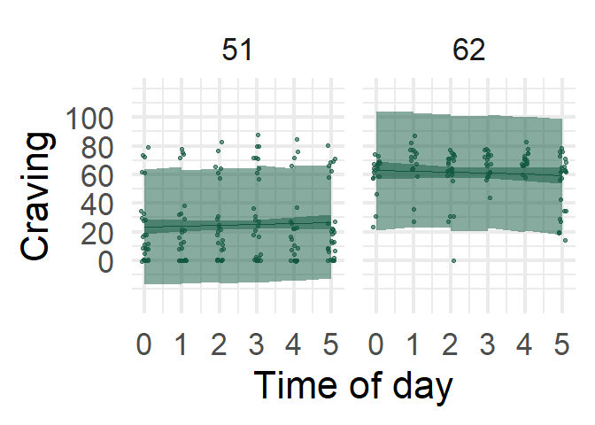

```r
nd <-
  d %>%
  filter(alias %in% c("SLHR1002","UERL0203")) %>%
  select(alias,id, craving, signal)

MLM1_preds = bind_cols(
  # fitted
  fitted(MLM1, newdata = nd,probs = c(0.05, 0.95)) %>%
    data.frame(),
  # predict
  predict(MLM1, newdata = nd,probs = c(0.05, 0.95)) %>%
    data.frame() %>%
    select(Q5:Q95) %>%
    setNames(c("p_lower", "p_upper"))) %>%
  bind_cols(nd)

ggplot(data=MLM1_preds,aes(x = signal)) +
  geom_smooth(aes(y = Estimate, ymin = Q5, ymax = Q95),
              stat = "identity",
              fill = "#115740", color = "#115740", alpha = 1/2, linewidth = 1/2) +
  geom_ribbon(aes(ymin = p_lower, ymax = p_upper),
              fill = "#115740", alpha = 1/2) +
  geom_point(aes(y = craving),
             color = "#115740",alpha=0.6,position=position_jitter(width=0.1)) +
  ylab("Craving") + xlab("Time of day")+coord_cartesian(ylim = c(-30, 120)) +
  scale_y_continuous(breaks = seq(0, 100, 20))+
  facet_wrap(~ id)+theme_minimal(base_size=32)
```

both participants have the same 90% credible interval since the estimated variance for both is the same!

## Mixed-Effects Location Scale Model

```r
bMELS1 = brm(
  formula=bf(
    craving ~ 1 + signal + (1 + signal |i| alias),
    sigma ~ 1  + signal + (1 + signal |i| alias)),

     prior = c( #for mean intercept, factors and varying effects (expressed as variation from mean)
                prior(normal(20, 10), class = Intercept),
                prior(normal(0, 5), class = b),
                prior(exponential(2), class = sd), # rate=1 might be a bit strict
                # for sigma-specific parameters
                prior(normal(0, 10), class = Intercept, dpar = sigma),
                prior(exponential(2), class = sd, dpar = sigma),
                #prior on varying effects correlations
                prior(lkj(2), class = cor)),
  family = brmsfamily("gaussian",link_sigma = "log"),
  data=d, iter=2000,
  file="bMELS1",file_refit = "on_change")

bMELS1
```

```
##  Family: gaussian
##   Links: mu = identity; sigma = log
## Formula: craving ~ 1 + signal + (1 + signal | i | alias)
##          sigma ~ 1 + signal + (1 + signal | i | alias)
##    Data: d (Number of observations: 9882)
##   Draws: 4 chains, each with iter = 2000; warmup = 1000; thin = 1;
##          total post-warmup draws = 4000
##
## Multilevel Hyperparameters:
## ~alias (Number of levels: 64)
##                                   Estimate Est.Error l-95% CI u-95% CI Rhat
## sd(Intercept)                        14.77      1.06    12.89    17.03 1.00
## sd(signal)                            2.29      0.24     1.86     2.78 1.00
## sd(sigma_Intercept)                   0.41      0.04     0.34     0.50 1.00
## sd(sigma_signal)                      0.07      0.01     0.06     0.09 1.00
## cor(Intercept,signal)                -0.38      0.09    -0.56    -0.19 1.00
## cor(Intercept,sigma_Intercept)        0.16      0.10    -0.04     0.36 1.00
## cor(signal,sigma_Intercept)          -0.09      0.12    -0.32     0.15 1.00
## cor(Intercept,sigma_signal)          -0.09      0.11    -0.31     0.13 1.00
## cor(signal,sigma_signal)              0.55      0.10     0.34     0.73 1.00
## cor(sigma_Intercept,sigma_signal)    -0.48      0.11    -0.66    -0.24 1.00
##                                   Bulk_ESS Tail_ESS
## sd(Intercept)                         1016     1441
## sd(signal)                            2138     3042
## sd(sigma_Intercept)                   1538     2229
## sd(sigma_signal)                      1832     2829
## cor(Intercept,signal)                 1369     2068
## cor(Intercept,sigma_Intercept)        1030     1772
## cor(signal,sigma_Intercept)            879     1637
## cor(Intercept,sigma_signal)           1676     2748
## cor(signal,sigma_signal)              1887     2309
## cor(sigma_Intercept,sigma_signal)     2147     2717
##
## Regression Coefficients:
##                 Estimate Est.Error l-95% CI u-95% CI Rhat Bulk_ESS Tail_ESS
## Intercept          28.93      1.93    25.24    32.73 1.01      462      893
## sigma_Intercept     3.01      0.05     2.90     3.11 1.00      784     1105
## signal             -0.00      0.32    -0.62     0.65 1.00     1224     1878
## sigma_signal        0.03      0.01     0.01     0.05 1.00     1473     2575
##
## Draws were sampled using sampling(NUTS). For each parameter, Bulk_ESS
## and Tail_ESS are effective sample size measures, and Rhat is the potential
## scale reduction factor on split chains (at convergence, Rhat = 1).
```

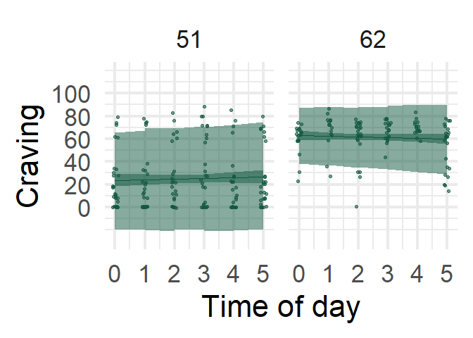

```r
nd <-
  d %>%
  filter(alias %in% c("SLHR1002","UERL0203")) %>%
  select(alias,id, craving, signal)

bMELS1_preds = bind_cols(
  # fitted
  fitted(bMELS1, newdata = nd,probs = c(0.05, 0.95)) %>%
    data.frame(),
  # predict
  predict(bMELS1, newdata = nd,probs = c(0.05, 0.95)) %>%
    data.frame() %>%
    select(Q5:Q95) %>%
    setNames(c("p_lower", "p_upper"))) %>%
  bind_cols(nd)

ggplot(data=bMELS1_preds,aes(x = signal)) +
  geom_smooth(aes(y = Estimate, ymin = Q5, ymax = Q95),
              stat = "identity",
              fill = "#115740", color = "#115740", alpha = 1/2, linewidth = 1/2) +
  geom_ribbon(aes(ymin = p_lower, ymax = p_upper),
              fill = "#115740", alpha = 1/2) +
  geom_point(aes(y = craving),
             color = "#115740",alpha=0.6,position=position_jitter(width=0.1)) +
  ylab("Craving") + xlab("Time of day")+ coord_cartesian(ylim = c(-30, 120)) +
  scale_y_continuous(breaks = seq(0, 100, 20))+
  facet_wrap(~ id)+theme_minimal(base_size=32)
```

-> the credible interval for the second participant is more narrow and closer to the actual data, the predictive accuracy is improved.

# adding stressor presence to model for both

```r
bMELS2 = brm(
  formula=bf(
    craving ~ 1 + signal + stressor + (1 + stressor + signal |i| alias),
    sigma ~ 1 + signal + stressor + (1 + stressor + signal |i| alias)),
    prior = c( #for mean intercept, factors and varying effects (expressed as variation from mean)
              prior(normal(20, 10), class = Intercept),
              prior(normal(0, 5), class = b),
              prior(exponential(2), class = sd), # rate=1 might be a bit strict
              # for sigma-specific parameters
              prior(normal(0, 10), class = Intercept, dpar = sigma),
              prior(exponential(2), class = sd, dpar = sigma),
              #prior on varying effects correlations
              prior(lkj(2), class = cor)),
  family = brmsfamily("gaussian",link_sigma = "log"),
  data=d, iter=4000,chains=4,cores=4,
  file="bMELS2",file_refit = "on_change")
summary(bMELS2,prob=0.9)
```

```
##  Family: gaussian
##   Links: mu = identity; sigma = log
## Formula: craving ~ 1 + signal + stressor + (1 + stressor + signal | i | alias)
##          sigma ~ 1 + signal + stressor + (1 + stressor + signal | i | alias)
##    Data: d (Number of observations: 9648)
##   Draws: 4 chains, each with iter = 4000; warmup = 2000; thin = 1;
##          total post-warmup draws = 8000
##
## Multilevel Hyperparameters:
## ~alias (Number of levels: 64)
##                                     Estimate Est.Error l-90% CI u-90% CI Rhat
## sd(Intercept)                          14.87      1.05    13.22    16.67 1.00
## sd(stressor)                            2.99      0.81     1.66     4.30 1.00
## sd(signal)                              2.24      0.24     1.87     2.64 1.00
## sd(sigma_Intercept)                     0.41      0.04     0.35     0.48 1.00
## sd(sigma_stressor)                      0.15      0.03     0.11     0.20 1.00
## sd(sigma_signal)                        0.07      0.01     0.06     0.08 1.00
## cor(Intercept,stressor)                -0.14      0.16    -0.40     0.13 1.00
## cor(Intercept,signal)                  -0.36      0.09    -0.50    -0.20 1.00
## cor(stressor,signal)                   -0.20      0.20    -0.52     0.13 1.00
## cor(Intercept,sigma_Intercept)          0.16      0.10    -0.01     0.32 1.00
## cor(stressor,sigma_Intercept)          -0.10      0.17    -0.36     0.19 1.01
## cor(signal,sigma_Intercept)            -0.03      0.13    -0.24     0.18 1.00
## cor(Intercept,sigma_stressor)          -0.12      0.14    -0.35     0.12 1.00
## cor(stressor,sigma_stressor)            0.66      0.16     0.38     0.87 1.00
## cor(signal,sigma_stressor)             -0.14      0.16    -0.40     0.13 1.00
## cor(sigma_Intercept,sigma_stressor)    -0.09      0.16    -0.35     0.19 1.00
## cor(Intercept,sigma_signal)            -0.07      0.11    -0.25     0.11 1.00
## cor(stressor,sigma_signal)             -0.16      0.19    -0.47     0.14 1.00
## cor(signal,sigma_signal)                0.52      0.10     0.34     0.68 1.00
## cor(sigma_Intercept,sigma_signal)      -0.40      0.12    -0.58    -0.20 1.00
## cor(sigma_stressor,sigma_signal)       -0.39      0.17    -0.66    -0.09 1.00
##                                     Bulk_ESS Tail_ESS
## sd(Intercept)                           1539     2662
## sd(stressor)                            1888     1254
## sd(signal)                              3961     5576
## sd(sigma_Intercept)                     2424     4027
## sd(sigma_stressor)                      4820     5354
## sd(sigma_signal)                        4106     5880
## cor(Intercept,stressor)                 6514     3709
```

[output cut: 12 more lines]

```
## cor(sigma_Intercept,sigma_signal)       4007     5495
## cor(sigma_stressor,sigma_signal)        2797     5178
##
## Regression Coefficients:
##                 Estimate Est.Error l-90% CI u-90% CI Rhat Bulk_ESS Tail_ESS
## Intercept          29.04      1.92    25.88    32.10 1.01      657     1301
## sigma_Intercept     3.00      0.05     2.91     3.09 1.00     1449     2902
## signal              0.01      0.32    -0.51     0.54 1.00     1932     3322
## stressor           -0.44      0.72    -1.64     0.74 1.00     3289     5286
## sigma_signal        0.03      0.01     0.01     0.05 1.00     3103     4480
## sigma_stressor      0.02      0.03    -0.02     0.07 1.00     5408     5708
##
## Draws were sampled using sampling(NUTS). For each parameter, Bulk_ESS
## and Tail_ESS are effective sample size measures, and Rhat is the potential
## scale reduction factor on split chains (at convergence, Rhat = 1).
```

## fixed effects for stressor and time of day

with dpar=TRUE, we receive a column for sigma and for mu

```r
bMELS2_epred <- d %>%
                data_grid(signal,stressor)%>% add_epred_rvars(bMELS2,dpar=TRUE,allow_new_levels=TRUE)
```

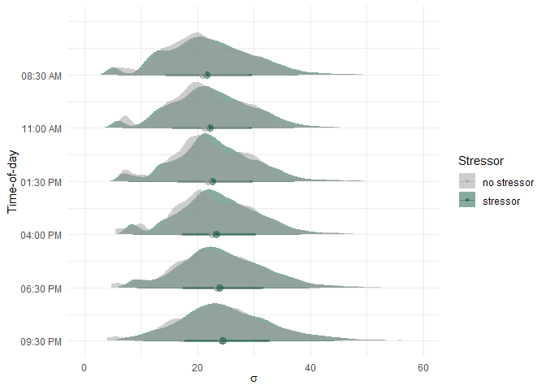

```r
ggplot(bMELS2_epred, aes(xdist = sigma, y = signal, fill = factor(stressor),colour=factor(stressor))) +
   stat_halfeye(alpha=0.5) +
  scale_y_reverse(breaks=seq(0,5,1),labels=c("0" = "08:30 AM","1" = "11:00 AM","2" = "01:30 PM","3" = "04:00 PM","4" = "06:30 PM","5" = "09:30 PM"))+
  scale_fill_manual(
    values = c("0" = "#9C9C9C", "1" = "#115740"),
    labels = c("0" = "no stressor", "1" = "stressor"),
    name   = "Stressor") +
    scale_colour_manual(
    values = c("0" = "#9C9C9C", "1" = "#115740"),
    labels = c("0" = "no stressor", "1" = "stressor"),
    name   = "Stressor") +
  xlim(0,60)+
  ylab("Time-of-day")+xlab(expression(sigma))+
  theme_minimal()
```

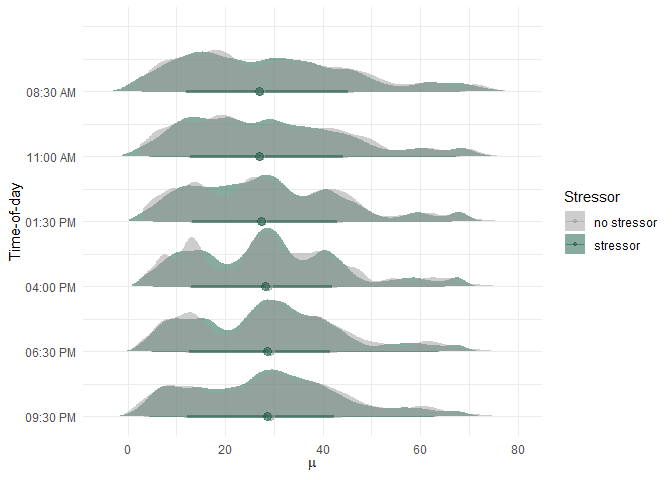

```r
ggplot(bMELS2_epred, aes(xdist = mu, y = signal, fill = factor(stressor),colour=factor(stressor))) +
  #stat_dotsinterval(quantiles = 100, alpha = 0.6) +
   stat_halfeye(alpha=0.5) +
  scale_y_reverse(breaks=seq(0,5,1),labels=c("0" = "08:30 AM","1" = "11:00 AM","2" = "01:30 PM","3" = "04:00 PM","4" = "06:30 PM","5" = "09:30 PM"))+
  scale_fill_manual(
    values = c("0" = "#9C9C9C", "1" = "#115740"),
    labels = c("0" = "no stressor", "1" = "stressor"),
    name   = "Stressor") +
    scale_colour_manual(
    values = c("0" = "#9C9C9C", "1" = "#115740"),
    labels = c("0" = "no stressor", "1" = "stressor"),
    name   = "Stressor") +
  #xlim(0,60)+
  ylab("Time-of-day")+xlab(expression(mu))+
  theme_minimal()
```

## covariance matrix

```r
rho <-
  posterior_summary(bMELS2) %>%
  data.frame() %>%
  rownames_to_column("param") %>%
  filter(str_detect(param, "cor_")) %>%
  mutate(param = str_remove(param, "cor_alias__")) %>%
  separate(param, into = c("left", "right"), sep = "__") %>%
  mutate(label = formatC(Estimate, digits = 2, format = "f") %>% str_replace(., "0.", "."))

rho_ord = rho
rho_ord$left=factor(rho_ord$left,
                            levels=c("Intercept","stressor","signal","sigma_Intercept","sigma_stressor"),ordered=T,
                            labels=c("alpha","S[mu]","ToD[mu]","alpha[sigma]","S[sigma]"))
rho_ord$right=factor(rho_ord$right,
                            levels=c("sigma_signal","sigma_stressor","sigma_Intercept","signal","stressor"),ordered=T,
                            labels=c("ToD[sigma]","S[sigma]","alpha[sigma]","ToD[mu]","S[mu]"))
```

plotting

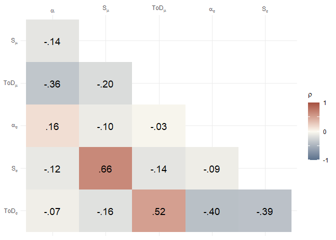

```r
rho_ord %>%
  ggplot(aes(x = left, y = right)) +
  geom_tile(aes(fill = Estimate)) +
  geom_text(aes(label = label),size=5,
            family = "Franklin Gothic Book") +
  scale_fill_gradient2(expression(rho),
                       low = "#59708b", mid = "#FCF9F0", high = "#A65141", midpoint = 0,
                       labels = c(-1, "", 0, "", 1), limits = c(-1, 1)) +
  scale_x_discrete(NULL, drop = F, labels = ggplot2:::parse_safe, position = "top") +
  scale_y_discrete(NULL, drop = F, labels = ggplot2:::parse_safe) +
  theme(axis.text = element_text(),
        axis.ticks = element_blank(),
        legend.text = element_text(hjust = 1))+theme_minimal()
```

# Bonus: with interaction between stressor and signal

```r
bMELS2b = brm(
  formula=bf(
    craving ~ 1 + signal * stressor + (1 + stressor + signal |i| alias),
    sigma ~ 1 + signal * stressor + (1 + stressor + signal |i| alias)),
    prior = c( #for mean intercept, factors and varying effects (expressed as variation from mean)
              prior(normal(20, 10), class = Intercept),
              prior(normal(0, 5), class = b),
              prior(exponential(2), class = sd), # rate=1 might be a bit strict
              # for sigma-specific parameters
              prior(normal(0, 10), class = Intercept, dpar = sigma),
              prior(exponential(2), class = sd, dpar = sigma),
              #prior on varying effects correlations
              prior(lkj(2), class = cor)),
  family = brmsfamily("gaussian",link_sigma = "log"),
  data=d, iter=2000,chains=4,cores=4,
  file="bMELS2b",file_refit = "on_change")

summary(bMELS2b,prob=0.9)
```

```
##  Family: gaussian
##   Links: mu = identity; sigma = log
## Formula: craving ~ 1 + signal * stressor + (1 + stressor + signal | i | alias)
##          sigma ~ 1 + signal * stressor + (1 + stressor + signal | i | alias)
##    Data: d (Number of observations: 9648)
##   Draws: 4 chains, each with iter = 2000; warmup = 1000; thin = 1;
##          total post-warmup draws = 4000
##
## Multilevel Hyperparameters:
## ~alias (Number of levels: 64)
##                                     Estimate Est.Error l-90% CI u-90% CI Rhat
## sd(Intercept)                          14.92      1.06    13.29    16.76 1.00
## sd(stressor)                            2.91      0.89     1.37     4.32 1.01
## sd(signal)                              2.17      0.23     1.80     2.58 1.00
## sd(sigma_Intercept)                     0.40      0.04     0.34     0.47 1.00
## sd(sigma_stressor)                      0.16      0.03     0.11     0.20 1.00
## sd(sigma_signal)                        0.07      0.01     0.05     0.08 1.00
## cor(Intercept,stressor)                -0.13      0.16    -0.38     0.15 1.00
## cor(Intercept,signal)                  -0.37      0.09    -0.52    -0.21 1.00
## cor(stressor,signal)                   -0.19      0.20    -0.52     0.16 1.00
## cor(Intercept,sigma_Intercept)          0.15      0.10    -0.02     0.32 1.00
## cor(stressor,sigma_Intercept)          -0.10      0.17    -0.37     0.18 1.02
## cor(signal,sigma_Intercept)            -0.01      0.13    -0.21     0.20 1.00
## cor(Intercept,sigma_stressor)          -0.11      0.14    -0.34     0.13 1.00
## cor(stressor,sigma_stressor)            0.63      0.18     0.34     0.85 1.01
## cor(signal,sigma_stressor)             -0.11      0.17    -0.39     0.17 1.00
## cor(sigma_Intercept,sigma_stressor)    -0.09      0.17    -0.36     0.19 1.00
## cor(Intercept,sigma_signal)            -0.07      0.11    -0.26     0.11 1.00
## cor(stressor,sigma_signal)             -0.12      0.21    -0.47     0.22 1.00
## cor(signal,sigma_signal)                0.50      0.11     0.31     0.67 1.00
## cor(sigma_Intercept,sigma_signal)      -0.39      0.12    -0.57    -0.19 1.00
## cor(sigma_stressor,sigma_signal)       -0.38      0.18    -0.65    -0.07 1.00
##                                     Bulk_ESS Tail_ESS
## sd(Intercept)                            656     1631
## sd(stressor)                             302      139
## sd(signal)                              1771     2374
## sd(sigma_Intercept)                     1457     2401
## sd(sigma_stressor)                      2075     2642
## sd(sigma_signal)                        2066     2831
## cor(Intercept,stressor)                 2742     1136
```

[output cut: 23 more lines]

```
## sigma_stressor           -0.04      0.04    -0.11     0.02 1.00     2804
## sigma_signal:stressor     0.03      0.01     0.01     0.05 1.00     3862
##                       Tail_ESS
## Intercept                  806
## sigma_Intercept           1553
## signal                    2044
## stressor                  2616
## signal:stressor           2871
## sigma_signal              2781
## sigma_stressor            2905
## sigma_signal:stressor     2812
##
## Draws were sampled using sampling(NUTS). For each parameter, Bulk_ESS
## and Tail_ESS are effective sample size measures, and Rhat is the potential
## scale reduction factor on split chains (at convergence, Rhat = 1).
```

*interesting interaction for both mean and sigma*